# Medidas de tendencia central

[Mildred Miranda](https://mildredmiranda16.github.io)

Estadística 2022-2, [Facultad de economía](http://www.economia.unam.mx/)

2/3/2022

### 1. ¿Qué son las medidas de tendencia central? 🤔

> *“Las medidas de tendencia central son parámetros estadísticos que informan sobre el centro de la distribución de la [muestra](https://economipedia.com/definiciones/muestra-estadistica.html)o [población estadística](https://economipedia.com/definiciones/poblacion-estadistica.html). Se encargan de resumir información del conjunto de datos numericos.”*

[Economipedia (2022)](https://economipedia.com/definiciones/medidas-de-tendencia-central.html)

Para este ejemplo, primero generaremos una serie de **100** números aleatorios entre **1** y **20** mediante la función `sample`. El argumento `TRUE` nos permitirá generar una muestra con remplazo:

```r
numeros <- sample(1:20, 100, TRUE)
numeros
```

```
##   [1] 18 15  6 13 10  2  8 20 11  3 13 18  9  1 14 17 18 19 10 14 20 11 10 17  5
##  [26]  4 13  4 10 18  9 10 20  5  8 13  1  6  6  6 16 17  3 17  8 11 14 16 20 14
##  [51] 12  8 10  7 17  6  7 15 18 16  8 15 20  8  3 11 12 19  8 15  1 14  5  4  5
##  [76] 14 17 10  1 11  2  9 11  3 10  3  3 18 10  5  7 12  6 13  8  6 20 11 16 13
```

### 2. Mediana 📍

> *“La mediana es un conjunto es un valor que se encuentra a la mitad de los otros valores, es decir, que al ordenar los número de menor a mayor, éste se encuentra justamente en medio entre los que están por arriba.”*

[QuestionPro (2022)](https://www.questionpro.com/blog/es/la-media-la-mediana-y-la-moda/)

Para obtener la **mediana**, podemos ordenar los `numeros` de menor a mayor, **el número que esté en medio de la muestra será la mediana**. Si utilizamos R, se puede hacer el cálculo de la **mediana** con la función `median`:

```r
mediana <- median(numeros)
mediana
```

```
## [1] 10.5
```

### 3. Media 🧮

> *“En [matemáticas](https://es.wikipedia.org/wiki/Matem%C3%A1ticas) y [estadística](https://es.wikipedia.org/wiki/Estad%C3%ADstica), una **media** o **promedio** es una [medida de tendencia central](https://es.wikipedia.org/wiki/Medida_de_tendencia_central). Resulta al efectuar una serie determinada de operaciones con un conjunto de números y que, en determinadas condiciones, puede representar por sí solo a todo el conjunto”*

Wikipedia (2022)

$$Media ={\frac {1}{n}}\sum _{i=1}^{n}a_{i}={\frac {a_{1}+a_{2}+\cdots +a_{n}}{n}}$$

Si usamos R, podemos obtener la media de una muestra si utlilizamos la función **mean**:

```r
media <- mean(numeros)
media
```

```
## [1] 10.74
```

### 4. Moda 📊

> “En la estadística, la moda es el valor que aparece con mayor frecuencia en un conjunto de datos. Esto va en forma de una columna cuando encontremos dos modas, es decir, dos datos que tengan la misma frecuencia absoluta máxima. Una distribución trimodal de los datos es en la que encontramos tres modas.”

Wikipedia (2022)

Podemos saber cuál es la **frecuencia** (número de veces que aparece un elemento en una muestra) de cada número si dibujamos un **histograma** con la función `hist`, **aquel elemento con mayor frecuencia será la moda**:

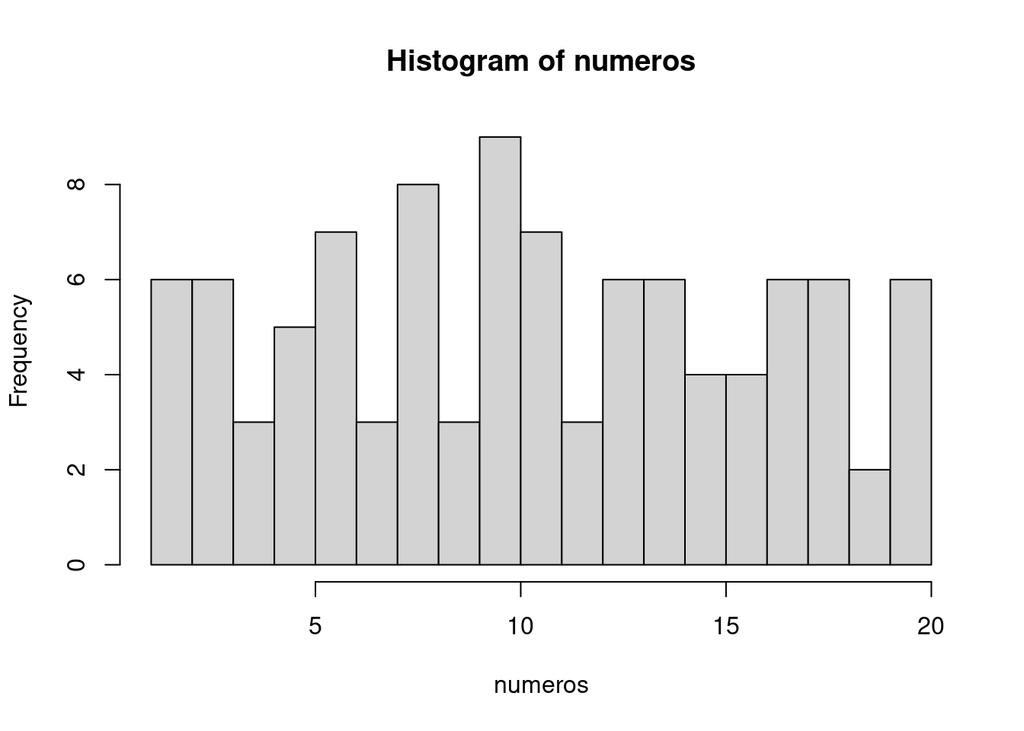

```r
# El argumento breaks nos permite dividir en histograma en las partes que queramos
hist(numeros, breaks = 20)
```

Para obtener un resultado con más precisión, podemos obtener la **moda** si generamos una **tabla de frecuencias** con la función `table` y la función `data.frame`, **aquel elemento con mayor frecuencia será la moda**:

```r
tabla.frecuencias <- data.frame(table(numeros))
tabla.frecuencias
```

```
##    numeros Freq
## 1        1    4
## 2        2    2
## 3        3    6
## 4        4    3
## 5        5    5
## 6        6    7
## 7        7    3
## 8        8    8
## 9        9    3
## 10      10    9
## 11      11    7
## 12      12    3
## 13      13    6
## 14      14    6
## 15      15    4
## 16      16    4
## 17      17    6
## 18      18    6
## 19      19    2
## 20      20    6
```

### 5. Ejercicio 👩‍💻👨‍💻✍

Aplica lo que aprendiste, obten la **mediana**, **media** y **moda** de la siguiente muestra de números:

```r
# Con la función seq, creamos una secuencia de 1 a 10 en intervalos de 0.1 en 0.1
secuencia <- seq(1, 10, 0.1)
muestra <- sample(secuencia, 100, TRUE)
muestra
```

```
##   [1]  7.5  9.2  6.7  1.9  6.5  9.1  8.1  1.6  9.7  6.9  6.8  4.4  8.9  2.7  5.0
##  [16]  1.2  7.6  1.0  7.0  9.7  9.3  7.4  4.0  3.7  2.2  5.0  5.1  6.7  2.8  5.3
##  [31]  2.9  8.6 10.0  1.0  7.8  5.4 10.0  8.8  4.8  9.8  3.8  2.8  8.5  5.4  9.8
##  [46]  6.4  2.7  3.3  6.2  6.0  1.6  4.4  4.9  6.8  8.8  5.0  3.3  7.5  7.3  1.5
##  [61]  5.6  2.1  3.9  3.6  8.6  8.5  9.9  9.4  5.6  4.6  4.5  5.0  3.7  1.0  9.7
##  [76]  3.5  1.3  7.6  2.8  3.0  1.8  4.3  1.7  1.8  4.0  1.1  7.2  1.4  4.2  3.5
##  [91]  9.1  9.6  9.8  6.7  7.3  8.7  9.2  3.3  1.1  5.6
```

##### Mediana

```r
# Aquí el cálculo de la mediana
mediana.muestra <- median(muestra)
mediana.muestra
```

```
## [1] 5.35
```

##### Media

```r
# Aquí el cálculo de la media
media.muestra <- mean(muestra)
media.muestra
```

```
## [1] 5.534
```

##### Moda

```r
# Aquí el cálculo de la moda
tabla.muestra <- data.frame(table(muestra))
tabla.muestra
```

```
##    muestra Freq
## 1        1    3
## 2      1.1    2
## 3      1.2    1
## 4      1.3    1
## 5      1.4    1
## 6      1.5    1
## 7      1.6    2
## 8      1.7    1
## 9      1.8    2
## 10     1.9    1
## 11     2.1    1
## 12     2.2    1
## 13     2.7    2
## 14     2.8    3
```

[output cut: 50 more lines]

💻[Código disponible en RStudio Cloud](https://rstudio.cloud/project/3671022)💻